# H1B Analysis

# Visualization 4: BoxPlot

```r
anova <- aov(h1b$Base_Salary ~ h1b$Case_Status)
summary(anova)
```

```
##                      Df    Sum Sq   Mean Sq F value Pr(>F)
## h1b$Case_Status       2 2.246e+12 1.123e+12    1045 <2e-16 ***
## Residuals       2030749 2.182e+15 1.075e+09
## ---
## Signif. codes:  0 '***' 0.001 '**' 0.01 '*' 0.05 '.' 0.1 ' ' 1
## 4607 observations deleted due to missingness
```

```r
TukeyHSD(anova)
```

```
##   Tukey multiple comparisons of means
##     95% family-wise confidence level
##
## Fit: aov(formula = h1b$Base_Salary ~ h1b$Case_Status)
##
## $`h1b$Case_Status`
##                          diff       lwr       upr p adj
## Denied-Certified    -8253.944 -8702.940 -7804.949     0
## Withdrawn-Certified -2119.247 -2424.617 -1813.877     0
## Withdrawn-Denied     6134.698  5597.344  6672.051     0
```

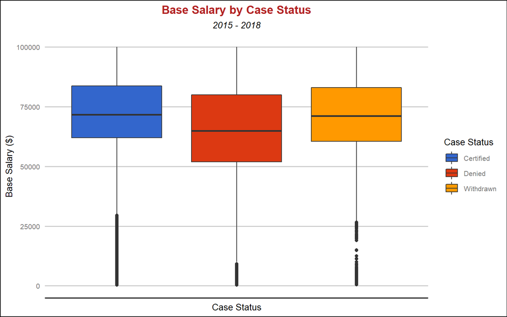

```r
ggplot(h1b) +
  geom_boxplot(aes(factor(Case_Status), Base_Salary, fill=as.factor(Case_Status))) +
  ylim(c(0, 100000)) +
  theme_gdocs() +
  scale_fill_gdocs() +
  theme(axis.text.x=element_blank()) +
  labs(title="Base Salary by Case Status", subtitle="2015 - 2018",
       x="Case Status", y="Base Salary ($)", fill="Case Status") +
  theme(plot.title = element_text(face="bold", color="firebrick", size=13, hjust=0.5),
        plot.subtitle = element_text(face="italic", size=10, color="black", hjust=0.5),
        panel.grid.major.x = element_blank(),
        legend.title = element_text(color="black", size=10),
        legend.text = element_text(size=8),
        axis.title = element_text(size=10, color="black"),
        axis.text = element_text(size=8))
```

### Insights

We wanted to check the salary differences in different H1B Status groups. First of all, we check the statistical results from the ANOVA test. Based on the results, we can see that the p-value is quite small, which means that there is significant difference among the means of all three groups. Then, we utilize the TukeyHSD test and find out that each pair of two random groups has signicant difference from each other.

To better visualize the comparison, we made the boxplot to show the distribution within each H1B Status group. It turns out that the one who got denied would tend to have lower salary while the certified and withdrawn groups have a 70k median salaries.

# Visualization 5: Monthly Trend

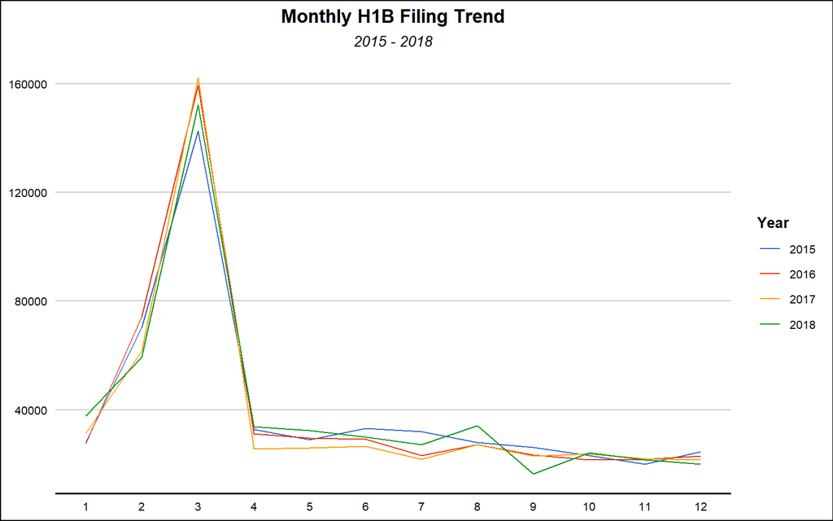

```r
case.month <-
  h1b %>%
  filter(Case_Status == 'Certified')
case.month = tapply(case.month$Case_Status, list(case.month$Submit_Month,case.month$Submit_Year), length)
case.month<-melt(case.month)
ggplot(case.month) +
  geom_line(aes(Var1,value,group=as.factor(Var2),color=as.factor(Var2))) +
  theme_gdocs() +
  scale_color_gdocs() +
  theme(axis.title.x=element_blank()) +
  scale_x_continuous(breaks=seq(1,12)) +
  labs(title="Monthly H1B Filing Trend", subtitle="2015 - 2018", color="Year") +
  theme(panel.grid.major.y = element_line(size=0.5),
        panel.grid.major.x = element_blank(),
        plot.title = element_text(face="bold", size=13, color="black", hjust=0.5),
        plot.subtitle = element_text(face="italic", size=10, color="black", hjust=0.5),
        legend.title = element_text(face="bold", size=10, color="black"),
        legend.text = element_text(size=8, color="black"),
        axis.title = element_blank(),
        axis.text = element_text(size=8, color="black"))
```

### Insights